# What Makes A Strong Student?

# Factors Affecting Academic Performance at UC Irvine

## Author: Alex Lucas

In this project, I will be using a dataset collected from Engineering and Educational Sciences students from the University of California, Irvine (UCI). In this dataset, students were surveyed on over 30 metrics such as income, parents’ education, time spent studying, level of attentiveness in class, and final grade in the course. The data can be accessed [here:](https://www.kaggle.com/datasets/mariazhokhova/higher-education-students-performance-evaluation)

Before getting into analysis of the data, it is worth recognizing the limitations of the data. The number of survey respondents is 145, which could be seen as relatively small. This may result in the data appearing less varied than the population truly is. It may also limit our ability to extrapolate from the data. However, 145 is not so small that the data is unreliable. It is generally recommended for a sample size to be over 100 to provide a meaningful representation of a large population such as college students across the United States. A larger sample size would certainly be more ideal, however inferences can still cautiously be made with this dataset.

In addition to the sample size being small, the data is not taken completely randomly from a population of American college students. It is taken from students in the Engineering and Educational Sciences at UC Irvine. Students at UCI may have different profiles from the average college student in America. Being one of the highest ranked public universities in the country, students at UCI may already be higher achieving academically. It would also be difficult to apply the findings from UCI data to a place like Oxford despite both being high achieving academically because student backgrounds are likely to be very different. Finally, the fact that the data was exclusively taken in the Engineering and Educational Sciences departments may make it difficult to extrapolate the findings to other subjects such as English or Economics. All of this is not to say that no inferences can be made based on the findings from this data. It is just important to consider these limitations and avoid making definitive claims that this data represents trends for all academic subjects and all colleges in the United States.

# Importing Libaries and the Data

```python
import pandas as pd
import numpy as np
import matplotlib.pyplot as plt
import math
from IPython.display import display, HTML

import os
os.chdir('/Users/alexlucas/PROJECTS')
print(os.getcwd())
```

```
/Users/alexlucas/PROJECTS
```

```python
performance_data = pd.read_csv('DATA.csv', delimiter = ';')
```

# Cleaning the Data

```python
#This code narrows the data down to only factors we are most interested in
performance_data = performance_data.iloc[:,[1,2,3,5,6,8,11,12,13,17,22,24,25,26,29,30,32]]
```

```python
#This code fixes a spelling error in the column name
performance_data = performance_data.rename(columns={'farther_ed':'father_ed'})
#This code shortens the column name to make it easier to work with
performance_data = performance_data.rename(columns={'attendances_classes':'attendance'})
#this code fixes a spelling error in the column name
performance_data = performance_data.rename(columns={'listenning':'listening'})

#This creates indices with combined numbers before replacing so that averages are quantified
performance_data['Parent Education Index'] = performance_data[['mother_ed', 'father_ed']].mean(axis=1)
performance_data['Circumstance Index'] = performance_data[['Parent Education Index', 'total_salary']].mean(axis=1)
performance_data['Work Ethic Index'] = performance_data[['weekly_study_hours','listening','taking_notes']].mean(axis=1)
```

# The given data is nearly all categorical and each category is represented by a number in each cell. One must refer to a data dictionary to fully understand the original data at all. Therefore, I replaced each number in the data with its corresponding category name in order to make the resulting tables readable.

```python
#This code does replacements for each number so that categorical labels can be read in tables.
performance_data['age'] = performance_data['age'].replace(1,'18-21')
performance_data['age'] = performance_data['age'].replace(2,'22-25')
performance_data['age'] = performance_data['age'].replace(3,'26+')

performance_data['sex'] = performance_data['sex'].replace(1,'Female')
performance_data['sex'] = performance_data['sex'].replace(2,'Male')

performance_data['graduated_h_school_type'] = performance_data['graduated_h_school_type'].replace(1,'Private')
performance_data['graduated_h_school_type'] = performance_data['graduated_h_school_type'].replace(2,'Public')
performance_data['graduated_h_school_type'] = performance_data['graduated_h_school_type'].replace(3,'Other')


performance_data['additional_work'] = performance_data['additional_work'].replace(1,'Yes')
performance_data['additional_work'] = performance_data['additional_work'].replace(2,'No')

performance_data['activity'] = performance_data['activity'].replace(1,'Yes')
performance_data['activity'] = performance_data['activity'].replace(2,'No')


performance_data['total_salary'] = performance_data['total_salary'].replace(1,'135-200')
performance_data['total_salary'] = performance_data['total_salary'].replace(2,'201-270')
performance_data['total_salary'] = performance_data['total_salary'].replace(3,'271-340')
performance_data['total_salary'] = performance_data['total_salary'].replace(4,'341-410')
performance_data['total_salary'] = performance_data['total_salary'].replace(5,'410+')


performance_data['mother_ed'] = performance_data['mother_ed'].replace(1,'Primary School')
performance_data['mother_ed'] = performance_data['mother_ed'].replace(2,'Secondary School')
performance_data['mother_ed'] = performance_data['mother_ed'].replace(3,'High School')
performance_data['mother_ed'] = performance_data['mother_ed'].replace(4,'University')
performance_data['mother_ed'] = performance_data['mother_ed'].replace(5,'Masters')
performance_data['mother_ed'] = performance_data['mother_ed'].replace(6,'Ph.D.')


performance_data['father_ed'] = performance_data['father_ed'].replace(1,'Primary School')
performance_data['father_ed'] = performance_data['father_ed'].replace(2,'Secondary School')
performance_data['father_ed'] = performance_data['father_ed'].replace(3,'High School')
performance_data['father_ed'] = performance_data['father_ed'].replace(4,'University')
performance_data['father_ed'] = performance_data['father_ed'].replace(5,'Masters')
performance_data['father_ed'] = performance_data['father_ed'].replace(6,'Ph.D.')


performance_data['weekly_study_hours'] = performance_data['weekly_study_hours'].replace(1,'None')
performance_data['weekly_study_hours'] = performance_data['weekly_study_hours'].replace(2,'<5 hours')
performance_data['weekly_study_hours'] = performance_data['weekly_study_hours'].replace(3,'6-10 hours')
performance_data['weekly_study_hours'] = performance_data['weekly_study_hours'].replace(4,'11-20 hours')
performance_data['weekly_study_hours'] = performance_data['weekly_study_hours'].replace(5,'20+ hours')


performance_data['attendance'] = performance_data['attendance'].replace(1,'Always')
performance_data['attendance'] = performance_data['attendance'].replace(2,'Sometimes')
performance_data['attendance'] = performance_data['attendance'].replace(3,'Never')


performance_data['preparation_midterm_time'] = performance_data['preparation_midterm_time'].replace(1,'Day Before Exam')
performance_data['preparation_midterm_time'] = performance_data['preparation_midterm_time'].replace(2,'Regularly During Semester')
performance_data['preparation_midterm_time'] = performance_data['preparation_midterm_time'].replace(3,'Never')


performance_data['taking_notes'] = performance_data['taking_notes'].replace(1,'Never')
performance_data['taking_notes'] = performance_data['taking_notes'].replace(2,'Sometimes')
performance_data['taking_notes'] = performance_data['taking_notes'].replace(3,'Always')


performance_data['listening'] = performance_data['taking_notes'].replace(1,'Never')
performance_data['listening'] = performance_data['taking_notes'].replace(2,'Sometimes')
performance_data['listening'] = performance_data['taking_notes'].replace(3,'Always')
```

To read the following graphs, one must understand the grading scale used in the data:

# The grades are on a scale of 0 to 7

# 0 = F

# 1 = D

# 2 = D+

# 3 = C

# 4 = C+

# 5 = B

# 6 = B+

# 7 = A

# To begin the analysis, I first want to look in general at the relationship between students’ circumstances and their grade.

# Here is a table showing the mean grade for each school type:

```python
#This code creates a table and bar graph of high school type vs. mean grades
school_type_table = performance_data.groupby(['graduated_h_school_type'])['grade'].mean()
school_type_table = school_type_table.reset_index()
display(HTML(school_type_table.to_html()))
```

|  | graduated_h_school_type | grade |
| --- | --- | --- |
| 0 | Other | 3.35 |
| 1 | Private | 2.60 |
| 2 | Public | 3.36 |

# Here is a bar chart showing the same relationship:

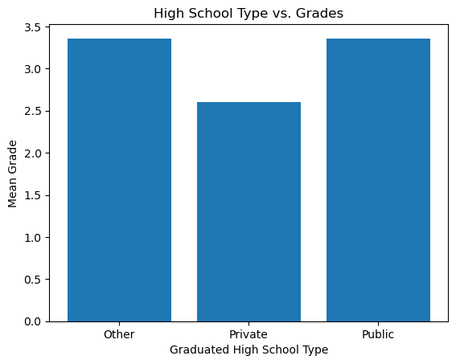

```python
plt.bar(school_type_table['graduated_h_school_type'],school_type_table['grade'])
plt.xlabel('Graduated High School Type')
plt.ylabel('Mean Grade')
plt.title('High School Type vs. Grades')
```

This table and bar chart demonstrate that students with public and other types of high school education tend to have higher grades than their privately educated counterparts. It would be interesting to see what the breakdown of types within the “Other” category are to see more in-depth. This relationship is slightly surprising as I would predict that private school-educated students would generally have come from better circumstances and higher quality education. This relationship could be explained by UC Irvine being a public institution, therefore public high school could possibly prepare students for this model of learning more effectively. It is also interesting to see the relationship between parents’ education and grades. I realized it was difficult to read a table that included every possible combination of education for the mother and father, so I created a Parent Education Index. Each level of education has a corresponding number in the data dictionary, so the Parent Education Index is made up of the mean of both numbers for mother and father education. The level of education goes in ascending order for each number, so it is simple to understand: the higher the Parent Education Index, the higher the average parent education.

This table shows each combination of education for mother and father and the corresponding mean grades.

```python
#This code creates a table for mother and father education vs. grade
mother_father_education_table = performance_data.groupby(['mother_ed','father_ed'])['grade'].mean()
mother_father_education_table = mother_father_education_table.to_frame()
display(HTML(mother_father_education_table.to_html()))
```

| mother_ed | father_ed | grade |
| --- | --- | --- |
| High School | High School | 2.32 |
|  | Masters | 3.00 |
|  | Primary School | 3.50 |
|  | Secondary School | 3.25 |
|  | University | 3.62 |
| Masters | Masters | 0.00 |
|  | University | 4.00 |
| Ph.D. | Masters | 7.00 |
|  | Primary School | 2.00 |
| Primary School | High School | 4.14 |
|  | Masters | 7.00 |
|  | Primary School | 2.70 |
|  | Secondary School | 2.67 |
|  | University | 2.00 |
| Secondary School | High School | 3.22 |
|  | Secondary School | 3.33 |
|  | University | 4.67 |
| University | High School | 4.00 |
|  | Ph.D. | 3.00 |
|  | Primary School | 6.00 |
|  | Secondary School | 5.50 |
|  | University | 3.33 |

This table shows the relationship between Parent Education Index and mean grade

```python
#This code creates a table for parent education index against grade
parent_education_table = performance_data.groupby('Parent Education Index')['grade'].mean()
parent_education_table = parent_education_table.to_frame()
display(HTML(parent_education_table.to_html()))
```

| Parent Education Index | grade |
| --- | --- |
| 1.0 | 2.70 |
| 1.5 | 2.67 |
| 2.0 | 3.69 |
| 2.5 | 3.26 |
| 3.0 | 3.04 |
| 3.5 | 3.62 |
| 4.0 | 3.29 |
| 4.5 | 4.00 |
| 5.0 | 1.50 |
| 5.5 | 7.00 |

Next, we can look at this graph which shows the correlation between salary and grades.

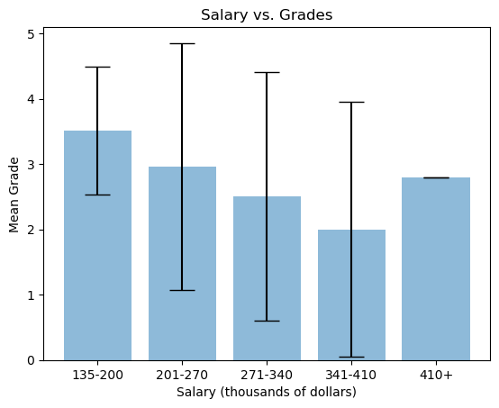

```python
#This code finds the error necessary for the error bars
group1_error = 1.96*((salary_table['std'].iloc[0]**2)/math.sqrt(salary_table['count'].iloc[0]))
group2_error = 1.96*((salary_table['std'].iloc[1]**2)/math.sqrt(salary_table['count'].iloc[1]))
group3_error = 1.96*((salary_table['std'].iloc[2]**2)/math.sqrt(salary_table['count'].iloc[2]))
group4_error = 1.96*((salary_table['std'].iloc[3]**2)/math.sqrt(salary_table['count'].iloc[3]))
group5_error = 1.96*((salary_table['std'].iloc[4]**2)/math.sqrt(salary_table['count'].iloc[4]))

#This code creates a bar graph with confidence intervals for the salary vs. grades
labels = ['135-200','201-270','271-340','341-410','410+']
means = [salary_table['mean'].iloc[0], salary_table['mean'].iloc[1], salary_table['mean'].iloc[2],
         salary_table['mean'].iloc[3],salary_table['mean'].iloc[4]]
x_pos = np.arange(len(means))
errors = [group1_error, group2_error, group3_error, group4_error, 0]

fig, ax = plt.subplots()
ax.bar(x_pos, means, yerr = errors, align='center', alpha=0.5, ecolor='black', capsize=10)
ax.set_xticks([0,1,2,3,4])
ax.set_xticklabels(labels)
ax.set_xlabel('Salary (thousands of dollars)')
ax.set_ylabel('Mean Grade')
ax.set_title('Salary vs. Grades')
```

I was very surprised looking at this dataset that the lowest salary group was $135,000-$200,000. When referring to salary, the original surveyor is likely referring to family income. I’m not sure if the original surveyor made a mistake. It is likely that students at UC Irvine have higher than average family income, however the lowest salary being $135,000 does not seem realistic. Otherwise, here is a bar chart showing the relationship between salary and mean grades with the confidence intervals shown.

# Work Ethic

Now, I want to move on from how circumstances affect grades and look at factors related to work ethic and how they relate to grades.

This table shows the relationship between listening and taking notes and mean grade.

```python
listening_notes_table = performance_data.groupby(['listening','taking_notes'])['grade'].mean()
listening_notes_table = listening_notes_table.to_frame()
display(HTML(listening_notes_table.to_html()))
```

| listening | taking_notes | grade |
| --- | --- | --- |
| Always | Always | 3.24 |
| Never | Never | 1.80 |
| Sometimes | Sometimes | 3.34 |

Unsurprisingly, those that always listen in class and take notes in class have higher grades than those that never listen and take notes. It is surprising however that those that sometimes listen and sometimes take notes had higher grades on average than the “always” camp. This could be explained by a talent factor.

This table shows whether a student has activities or work and their mean grades.

```python
work_activity_table = performance_data.groupby(['additional_work','activity'])['grade'].mean()
work_activity_table = work_activity_table.to_frame()
display(HTML(work_activity_table.to_html()))
```

| additional_work | activity | grade |
| --- | --- | --- |
| No | No | 3.26 |
|  | Yes | 3.97 |
| Yes | No | 2.68 |
|  | Yes | 2.74 |

The table above shows that those that do not have additional work, but do participate in an activity have the highest grades on average, while those that do work, but do not participate in an activity have the lowest grades. An explanation for this relationship could be that extracurricular activities, while they take up time, contribute more to better life satisfaction while additional work can be stressful and take up a lot of time.

This table shows how weekly study hours affect grades.

```python
#This code creates a table for weekly study hours vs. grades.
study_hours_table = performance_data.groupby(['weekly_study_hours'])['grade'].mean()
study_hours_table = study_hours_table.to_frame()
display(HTML(study_hours_table.to_html()))
```

| weekly_study_hours | grade |
| --- | --- |
| 11-20 hours | 2.88 |
| 20+ hours | 2.00 |
| 6-10 hours | 3.27 |
| <5 hours | 3.45 |
| None | 2.90 |

This table shows that there is actually a negative correlation between weekly study hours and grade. This is unexpected, however we can see that no studying results in relatively average grades, while less than 5 hours and 6-10 hours of studying results in the best grades of the pack. This shows that studying is helpful, however too much studying can actually have a negative effect and cause burnout and result in lower grades.

# Big Picture

So far, I have looked at how many specific factors affect grades. Now, I want to look generally at how factors related to circumstances affect grades and how factors related to work ethic affect grades. I created a circumstance index, which is made up of the mean of the parent education index and total salary. I also created a work ethic index, which is made up of the mean of weekly study hours, listening in class, and taking notes. This graph shows all data points and the trend of the relationship between circumstances and grades.

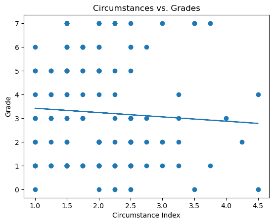

```python
#This code creates a scatter plot for circumstance index vs. grade
plt.figure()
plt.scatter(performance_data['Circumstance Index'],performance_data['grade'])
plt.xlabel('Circumstance Index')
plt.ylabel('Grade')
plt.title('Circumstances vs. Grades')

#This code makes a trendline for the above scatter plot.
polyn_coeff1 = np.polyfit(performance_data['Circumstance Index'],performance_data['grade'],1)
trendline1 = np.poly1d(polyn_coeff1)
y_axis_predicted1=trendline1(performance_data['Circumstance Index'])
plt.plot(performance_data['Circumstance Index'],y_axis_predicted1)
```

This graph shows all data points and the trend of the relationship between work ethic and grades.

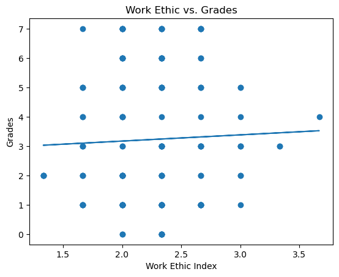

```python
#This code creates a scatter plot for the Work Ethic Index vs. Grades.
plt.figure()
plt.scatter(performance_data['Work Ethic Index'],performance_data['grade'])
plt.xlabel('Work Ethic Index')
plt.ylabel('Grades')
plt.title('Work Ethic vs. Grades')

#This code creates a trendline for the above scatter plot.
polyn_coeff2 = np.polyfit(performance_data['Work Ethic Index'],performance_data['grade'],1)
trendline2 = np.poly1d(polyn_coeff2)
y_axis_predicted2=trendline2(performance_data['Work Ethic Index'])
plt.plot(performance_data['Work Ethic Index'],y_axis_predicted2)
```

# Conclusion:

The big picture graphs showing the relationship between circumstances and grades as well as work ethic and grades demonstrate little to no correlation. The Circumstances vs. Grades graph has a trendline with a slight negative correlation and the Work Ethic vs. Grades graph has a trendline with a slight positive correlation. However, these correlations are not nearly strong enough to make a statement of causality.

Overall, there are some clear correlations for specific metrics such as listening in class, however a lot of times they are contradictory and result in the general relationships, such as work ethic, to have little to no correlation. This means that the data does not show any relationship between circumstances and grades or work ethic and grades.

Again, it is worth noting that the sample size of this dataset was small which could have affected the relationships we see in these tables and graphs. It may be interesting to see what the data would look like with a higher sample size.

# Reflection:

Was the assignment instructive and did it promote your learning? Yes, this assignment was instructive because I was able to apply the knowledge I learned from the previous 2 projects to a dataset I found myself and was interested in. It was definitely challenging to come up with my own route of analysis rather than following the questions of a project. I enjoyed this project and it helped me understand that the skills I have learned can be applied in the real world and could be used for a personal project or job.

# References-

https://www.kaggle.com/datasets/mariazhokhova/higher-education-students-performance-evaluation

https://archive.ics.uci.edu/ml/datasets/Higher+Education+Students+Performance+Evaluation+Dataset